# Effects of Migration from the Northeast on Las Vegas

Troy Wu

A census tract is a geographic region defined for the purpose of taking a census. Census tracts represent the smallest territorial entity for which population are available in many countries. In the Unites States, census tracts are subdivided into block groups and census blocks. The census tract provides a wide variety of information on things such as: average income, gender distribution, race, place of birth, method of commute, time of commute, and distribution of income. In this article, we are looking at the census tract of Las Vegas and finding out how the migration from residents from the northeast have impacted the data on Las Vegas.

Most people, if not all, were born from a different state or knows someone born from a different state than the one they currently reside. Most people however, don’t think about how the change of residence may affect the census data in a given location. These changes are different among regions as well as the specific location the residence comes from. In this article, I hope to reveal some of the affects caused by the migration into the Las Vegas census tract from the northeast.

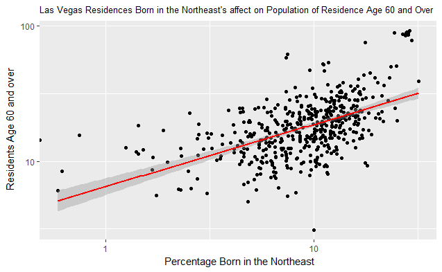

One point of interest is the general age of those born in the northeast. After looking at the age ranges of 0-17, 18-24, 25-59, and 60+ of residents born in the northeast. The most interesting age range that stood out was the ranges of those residents aged 60+. The census tract data shows that as the concentration of residents born in the northeast increases, so does the percentage of residents age 60 and over. The concentration of northeastern residents affect on the other age ranges on the other hand, has no strong correlation.

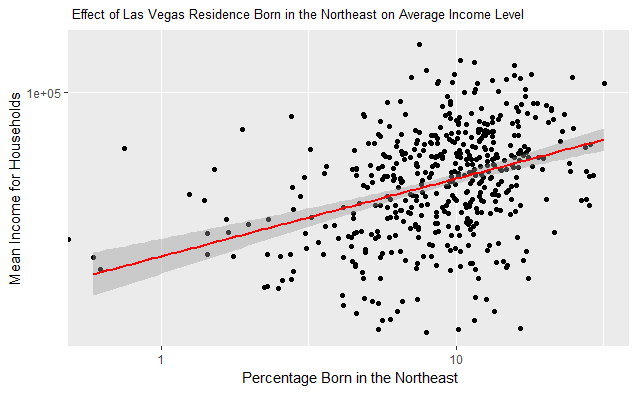

One major point of interest is income. How does the influx of residents from the northeast affect the income of the Las Vegas region? Generally, people are worried that the influx of new residences may hurt the income for the people in a community. To tackle this question, we determine how those residents from the northeast affect the average income in the area. To do this compare the percentage of residents born in the north east to the mean income for households in the third quartile (average of all household incomes). From this, we see that as the concentration of those born in the northeast increases so does the average household income in Las Vegas.

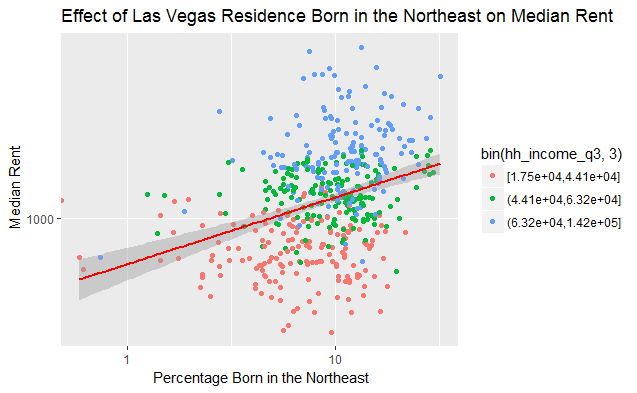

Alternatively, we see that the concentration of residents from the northeast has an impact on the median rent in Las Vegas. The census tract data shows that there is a positive correlation between the concentration of residents from the northeast and the median rent. However, this can be explained by the previous observation that in those areas where more residents were born in the northeast, there were a significant increase in the mean household income. The graph shows that as the percentage of residents born in the northeast increases, so does the rent. When you categorize the plots by average household income, we see that individuals who make the greater amount of income pay more in rent. This shows a possible correlation that residents who are born I the northeast who earn more income, generally are willing to pay more for rent.

Further research studying income earned and median rent may need to be studied to determine if a higher household income means that residents are willing to pay more for rent. Further research may be needed to determine how the larger income from northeastern natives affect prices of homes for those residents who wish to be homeowners instead of renting.